# File S2

## Kmers LOST during MA

```r
get_kmers_lost <- function (all_kmer_mx, nlines) {
  kmers.lost <- matrix(nrow=nrow(all_kmer_mx))
  for (i in 1:ncol(all_kmer_mx)) { ## go through each column of the data
    l <- all_kmer_mx[,i] == 0  ## 0 copies
    p <- all_kmer_mx[,i] > 1 ## present
    if (sum(l)==nlines && sum(p)==(nrow(all_kmer_mx)-nlines)) { # if there is only nlines line with 0 copies, and all others are present
      kmers.lost <- cbind(kmers.lost[, , drop=FALSE], all_kmer_mx[,i, drop=FALSE])
    }
  }
  kmers.lost <- kmers.lost[,2:ncol(kmers.lost)] # first column is NA
}

kmers.lost_1373 <- get_kmers_lost(kmers.all_1373, 1)
kmers.lost_1373
```

```
##                 C ACCAGGGGCGCCGGCAGC ACTGGCGCT AGCCAGGCGGG AGCAGGGGC
## CC-1373_MA1   109                  4         9           2        10
## CC-1373_MA2    68                 11         7          12         4
## CC-1373_MA3  2979                  4        18          13         5
## CC-1373_MA4     0                  0         0           6         6
## CC-1373_MA5    34                  7        13           2        11
## CC-1373_MA6    50                 10         6           6         0
## CC-1373_MA7    51                 10         8           7         8
## CC-1373_MA8    56                  9         7           4        13
## CC-1373_MA10  667                 11         4           6         3
## CC-1373_MA11  435                  5        10           6        12
## CC-1373_MA13   63                  9        11           0         9
## CC-1373_MA14 1930                  8         9           5        11
##              AGAGGCGGGGCC AGGCGGCCCC AGCGGCAGGCGC ACGGAGTGCCGCCG ACCACCCGC
## CC-1373_MA1             0          8           11              9        10
## CC-1373_MA2            14          8           19             10        10
## CC-1373_MA3             4         29           14              0        10
## CC-1373_MA4             5          8            0             26         0
## CC-1373_MA5             5         21           18              7         9
## CC-1373_MA6            12          0            6             13         3
## CC-1373_MA7            12         13            9             13         8
## CC-1373_MA8             4         16            9              7        11
## CC-1373_MA10            5          3           20              9        16
## CC-1373_MA11            7         18           15              7         2
## CC-1373_MA13            2         30           13              6         2
## CC-1373_MA14            9         24           10             17         7
##              ACCCGCAGCAGGCGC ACCGCACCGCACTGCGCCGC ACTGGGCCC AACACCCTCGC
## CC-1373_MA1                7                    5         2           3
## CC-1373_MA2               14                    7         6           4
## CC-1373_MA3                3                    7        11           2
## CC-1373_MA4                0                   16         0           0
## CC-1373_MA5               10                    6         4           3
## CC-1373_MA6               13                   19         3           4
## CC-1373_MA7                7                    0         6           5
## CC-1373_MA8               18                    7         3           2
## CC-1373_MA10               9                   11        11           3
## CC-1373_MA11              10                    8         7           3
## CC-1373_MA13              11                    7        13           4
## CC-1373_MA14              11                    4         4           3
##              ACCGTGGAGGCGGGG ACCAGCGCCAGC
## CC-1373_MA1                2            2
## CC-1373_MA2                0            4
## CC-1373_MA3                2            4
## CC-1373_MA4                4            0
## CC-1373_MA5                5            3
## CC-1373_MA6                2            3
## CC-1373_MA7                3            3
## CC-1373_MA8                5            3
## CC-1373_MA10               5            5
## CC-1373_MA11               4            2
## CC-1373_MA13               6            3
## CC-1373_MA14               2            3
```

```r
# 9 of the kmers were lost in MA line 4 - lost the poly C repear, among others.
colnames(kmers.lost_1373)
```

```
##  [1] "C"                    "ACCAGGGGCGCCGGCAGC"   "ACTGGCGCT"
##  [4] "AGCCAGGCGGG"          "AGCAGGGGC"            "AGAGGCGGGGCC"
##  [7] "AGGCGGCCCC"           "AGCGGCAGGCGC"         "ACGGAGTGCCGCCG"
## [10] "ACCACCCGC"            "ACCCGCAGCAGGCGC"      "ACCGCACCGCACTGCGCCGC"
## [13] "ACTGGGCCC"            "AACACCCTCGC"          "ACCGTGGAGGCGGGG"
## [16] "ACCAGCGCCAGC"
```

```r
kmers.lost_1952 <- get_kmers_lost(kmers.all_1952, 1)
kmers.lost_1952
```

```
##              AGGCGC CCG AGCGGC ACTGGC ACGGCG ACCTC AGCGCAGGCGGC AGCAGGCGC
## CC-1952_MA1     372 261    183     16     51    19           14        33
## CC-1952_MA2     335 252    238     14     35    14           76        18
## CC-1952_MA3     391 459    184     17     46    13           74        16
## CC-1952_MA4     350 494    221     13     25    14           58        17
## CC-1952_MA5     387 190    223     17     38     0           40        20
## CC-1952_MA6     370 334    188     11     31     9           70        14
## CC-1952_MA7     333 254    210     17     35    12           77        22
## CC-1952_MA8       0   0      0      0      0     5            0         0
## CC-1952_MA10    342 322    200     12     61    12           76        19
## CC-1952_MA11    402 230    287     13     22     7           46        50
## CC-1952_MA12    345 251    185     17     27    10           33        27
## CC-1952_MA13    252 315    170     18     34    15           79        17
## CC-1952_MA14    382 601    177     13     19    12           55        18
## CC-1952_MA15    369 459    179     16     38    10           77        20
##              AGGGCGGC AGGGGCC AAGGCGGCGCG AGCTGCCCC AGGCGGCGG
## CC-1952_MA1         3      16          28        11         7
## CC-1952_MA2        16      12          25        12        10
## CC-1952_MA3        34      12          12         7        19
## CC-1952_MA4        12       0           2         9        34
## CC-1952_MA5        17       7           9         0         6
## CC-1952_MA6        13       9          14         7        18
## CC-1952_MA7        17       5          26        10        14
## CC-1952_MA8         0      11           0         8         0
## CC-1952_MA10       31      14          22         9        17
## CC-1952_MA11        7       5          18        14         3
## CC-1952_MA12        9      23          30        18         5
## CC-1952_MA13       14      23          13        18        12
## CC-1952_MA14       22      12          17        12         8
## CC-1952_MA15       13      10          16        10        27
##              AGCCTCCTGGGGCGC AAGAGGG AGCAGCAGCAGG ACCGGCACTGGC ACCGCTGC
## CC-1952_MA1               10       6            4            6       14
## CC-1952_MA2                9       8            5            7       11
## CC-1952_MA3                3       3            4            9       13
## CC-1952_MA4                3       3            4           10       25
## CC-1952_MA5                0       0           11            0        7
## CC-1952_MA6                2       5            5            4       19
## CC-1952_MA7               10       2            4            7       11
## CC-1952_MA8               11       4            0            2        0
## CC-1952_MA10               3       5            4            3       13
```

[output cut: 50 more lines]

```
##              ACTGCTCCCCGC AGCAGCGGGAGCAGG AGCAGCCGCTGC
## CC-1952_MA1             5               4            2
## CC-1952_MA2             9               3            2
## CC-1952_MA3             6               2            2
## CC-1952_MA4             2               2            4
## CC-1952_MA5             0               6            3
## CC-1952_MA6             2               3            2
## CC-1952_MA7             3               4            3
## CC-1952_MA8             4               0            0
## CC-1952_MA10            2               3            4
## CC-1952_MA11            4               5            4
## CC-1952_MA12            5               3            2
## CC-1952_MA13            8               2            4
## CC-1952_MA14            4               5            2
## CC-1952_MA15            3               3            3
```

```r
colnames(kmers.lost_1952)
```

```
##  [1] "AGGCGC"             "CCG"                "AGCGGC"
##  [4] "ACTGGC"             "ACGGCG"             "ACCTC"
##  [7] "AGCGCAGGCGGC"       "AGCAGGCGC"          "AGGGCGGC"
## [10] "AGGGGCC"            "AAGGCGGCGCG"        "AGCTGCCCC"
## [13] "AGGCGGCGG"          "AGCCTCCTGGGGCGC"    "AAGAGGG"
## [16] "AGCAGCAGCAGG"       "ACCGGCACTGGC"       "ACCGCTGC"
## [19] "AGAGGCCCCC"         "AGCAGCC"            "ACAGGCGCCAGC"
## [22] "ACGGCGGCAGCAGTG"    "ACCGCCCTACGC"       "AGGAGGGGGCCTG"
## [25] "ACTGCCCCAGCAGCCGCC" "AAGCCGCAGCCGCGC"    "ACCTGCACCTGCTGCTGC"
## [28] "AGCTGCCGCCC"        "AGAGAGGAGGGC"       "AGGGCGCGGGCGGCATG"
## [31] "ACTGCTCCCCGC"       "AGCAGCGGGAGCAGG"    "AGCAGCCGCTGC"
```

```r
# total of 33 kmers were lost. 25 of them were lost in MA line 8

kmers.lost_2342 <- get_kmers_lost(kmers.all_2342, 1)
kmers.lost_2342
```

```
##                  C AGCGCC AGCCCC ACTGGC ACGGCC ACTGC ACAGCCC
## CC-2342_MA3   2459      0     23      0      0     5      11
## CC-2342_MA4   2864      7      7      5      7     2      12
## CC-2342_MA5  13656    103    196     25     21    13       8
## CC-2342_MA7    859    223      3     22     35    13       2
## CC-2342_MA8    625     94      8     14     12     8       8
## CC-2342_MA9   2357    184      7     13     11     0       3
## CC-2342_MA10   824    173      2     10     24     8       4
## CC-2342_MA11   649    156      2     12     31    11       3
## CC-2342_MA12     0    130      6     14     27     6       2
## CC-2342_MA13   326    105      0     13     18    11       0
## CC-2342_MA15    82    169      3     14     24    11       2
##              ACGGCAGCAGCAGCAGCG ACTGCTGC ACGCACGCGC AGGAGGCAGGGGC
## CC-2342_MA3                   3        0          0             0
## CC-2342_MA4                   0        2         10             6
## CC-2342_MA5                   7        7         15             4
## CC-2342_MA7                   3        8         47             9
## CC-2342_MA8                   4        8         37            25
## CC-2342_MA9                   7        4         40            20
## CC-2342_MA10                  5        3         37             7
## CC-2342_MA11                  4        8         17            12
## CC-2342_MA12                  4        9         19             6
## CC-2342_MA13                  3        8         18            11
## CC-2342_MA15                  3        9         20             6
##              AGGGCCAGGGGC AGCAGGC AAGGGGACGGCGGCGGCG ATGCCGC
## CC-2342_MA3             0       0                  0      10
## CC-2342_MA4            18       2                  2       0
## CC-2342_MA5            33       6                 12       8
## CC-2342_MA7            15       5                  8       2
## CC-2342_MA8             9       6                  5       4
## CC-2342_MA9             8       5                  3       2
## CC-2342_MA10           15       2                  8       3
## CC-2342_MA11            5       4                  5       3
## CC-2342_MA12            7       2                  4       4
## CC-2342_MA13            6       3                  8       4
## CC-2342_MA15            7       2                  8       4
##              AATCAGCGCCGCACACC ACATCCTCC
## CC-2342_MA3                  4         0
## CC-2342_MA4                  3         2
## CC-2342_MA5                  4         3
## CC-2342_MA7                  6         2
## CC-2342_MA8                  2         4
## CC-2342_MA9                  4         4
## CC-2342_MA10                 3         4
## CC-2342_MA11                 5         2
## CC-2342_MA12                 0         2
## CC-2342_MA13                 3         5
## CC-2342_MA15                 2         5
```

```r
colnames(kmers.lost_2342)
```

```
##  [1] "C"                  "AGCGCC"             "AGCCCC"
##  [4] "ACTGGC"             "ACGGCC"             "ACTGC"
##  [7] "ACAGCCC"            "ACGGCAGCAGCAGCAGCG" "ACTGCTGC"
## [10] "ACGCACGCGC"         "AGGAGGCAGGGGC"      "AGGGCCAGGGGC"
## [13] "AGCAGGC"            "AAGGGGACGGCGGCGGCG" "ATGCCGC"
## [16] "AATCAGCGCCGCACACC"  "ACATCCTCC"
```

```r
# 10/17 lost in MA line 3.

# the C repeat is highly variable here.

kmers.lost_2344 <- get_kmers_lost(kmers.all_2344, 1)
kmers.lost_2344
```

```
##              AGGGCC  A ACGCGC AGGGGC AGGGGCC AAGGGAGG ACATGGCGGGCACGGCCC
## CC-2344_MA1      20 10     10     18       3        4                 13
## CC-2344_MA2      12 28     26      4       4        2                 12
## CC-2344_MA3      10  7     12      4      18        3                  5
## CC-2344_MA4      12 22      0      0      25        2                  0
## CC-2344_MA5      14 38     19     15       5        3                 14
## CC-2344_MA6      11 20     17     23       0        6                 26
## CC-2344_MA7      12 15     24      8      16        3                 13
## CC-2344_MA8       3  9     24     12      11        3                 21
## CC-2344_MA9       7 11     31     13      12        2                 10
## CC-2344_MA10      9 15     18      3      11        3                 13
## CC-2344_MA11      5 37     40     20      32        0                  5
## CC-2344_MA12     15 27     31     12       3        3                 20
## CC-2344_MA13      0 12     42     34      22        3                 11
## CC-2344_MA14      7 51      4      9      11        2                 12
## CC-2344_MA15      4  0     43     16      14        3                 20
##              AGCCTCCGC ATCCCGGCCCC ACTCCCTCC ACAGCCGCAGCGGCAGGC
## CC-2344_MA1         13           3         3                  9
## CC-2344_MA2          9          11         6                  4
## CC-2344_MA3          0           4         3                  9
## CC-2344_MA4         13           3         3                  2
## CC-2344_MA5         18          11         4                  6
## CC-2344_MA6          9           0         2                  0
## CC-2344_MA7         24          11         5                  4
## CC-2344_MA8          6           7         5                  9
## CC-2344_MA9          7           9         4                  6
## CC-2344_MA10        15           6         6                 11
## CC-2344_MA11        16          15         0                  3
## CC-2344_MA12         6           2         2                  8
## CC-2344_MA13        20           8         5                  2
## CC-2344_MA14         5           6         5                  5
## CC-2344_MA15        11          10         4                  8
##              AAGGGAGTGGGAGG ACCGTGGAGGGC AAACATGGTTTGTGGACACC
## CC-2344_MA1               4            2                    2
## CC-2344_MA2               7            3                    3
## CC-2344_MA3               5            3                    3
## CC-2344_MA4               0            4                    3
## CC-2344_MA5               3            3                    4
## CC-2344_MA6               4            2                    0
## CC-2344_MA7               4            3                    3
## CC-2344_MA8               2            2                    3
## CC-2344_MA9               4            0                    2
## CC-2344_MA10              5            2                    2
## CC-2344_MA11              6            4                    3
## CC-2344_MA12              3            2                    3
## CC-2344_MA13              4            4                    2
## CC-2344_MA14              3            3                    3
## CC-2344_MA15              2            5                    4
```

```r
colnames(kmers.lost_2344)
```

```
##  [1] "AGGGCC"               "A"                    "ACGCGC"
##  [4] "AGGGGC"               "AGGGGCC"              "AAGGGAGG"
##  [7] "ACATGGCGGGCACGGCCC"   "AGCCTCCGC"            "ATCCCGGCCCC"
## [10] "ACTCCCTCC"            "ACAGCCGCAGCGGCAGGC"   "AAGGGAGTGGGAGG"
## [13] "ACCGTGGAGGGC"         "AAACATGGTTTGTGGACACC"
```

```r
# MA line 4 lost 4 and MA line 6 lost 4 (total 14)

kmers.lost_2931 <- get_kmers_lost(kmers.all_2931, 1)
kmers.lost_2931
```

```
##              ACGGCC AGGGCCGGGGCC AGCAGCAGCGGCGC AACAGGGGTGGTGGG
## CC-2931_MA1       7           18              5               3
## CC-2931_MA2      20            3              7               3
## CC-2931_MA3      27            0             10               2
## CC-2931_MA4      27            7             10               5
## CC-2931_MA5      15           12              8               3
## CC-2931_MA6      21            5              4               0
## CC-2931_MA7       8            2             13               3
## CC-2931_MA9      17            7             13               2
## CC-2931_MA10      4            5              8               3
## CC-2931_MA11      9           19             10               2
## CC-2931_MA12      7           20             10               2
## CC-2931_MA13      4            5             13               3
## CC-2931_MA14      7           11              0               2
## CC-2931_MA15      0            7              6               5
##              AGGCCGGAGGCGGG ACTGGGGCCGCCGGGGCC ACTGCCGCCGCC
## CC-2931_MA1               5                  2            4
## CC-2931_MA2               5                  5            6
## CC-2931_MA3               3                  4           10
## CC-2931_MA4               5                 13            9
## CC-2931_MA5               0                  6            9
## CC-2931_MA6               8                  7            0
## CC-2931_MA7               6                  4            5
## CC-2931_MA9               3                  4            3
## CC-2931_MA10              6                 15            8
## CC-2931_MA11              9                 11            9
## CC-2931_MA12              8                  4            2
## CC-2931_MA13              6                  4            7
## CC-2931_MA14              5                  0            4
## CC-2931_MA15             12                  9            4
##              ACTCCGCCTCCCGCTCCC ACCTCCCGGCCCCCAGG AAGGCGGGGCGAGGCC
## CC-2931_MA1                   4                 7                2
## CC-2931_MA2                   5                 2                5
## CC-2931_MA3                   9                 2                5
## CC-2931_MA4                   7                13               10
## CC-2931_MA5                   8                 8                7
## CC-2931_MA6                   6                 4               13
## CC-2931_MA7                   8                 7                2
## CC-2931_MA9                   2                 2                0
## CC-2931_MA10                  9                 5                8
## CC-2931_MA11                  6                 0               10
## CC-2931_MA12                  0                 8                2
## CC-2931_MA13                  3                10                2
## CC-2931_MA14                  5                 3                5
## CC-2931_MA15                  7                 6                3
##              AAGCGGGGCGGCG ACCCACCCCACGC
## CC-2931_MA1              5             2
## CC-2931_MA2              2             7
## CC-2931_MA3              7             2
## CC-2931_MA4              5            10
## CC-2931_MA5              7             5
## CC-2931_MA6              2             4
## CC-2931_MA7              2             4
## CC-2931_MA9              3             3
## CC-2931_MA10            10             4
## CC-2931_MA11             2             2
## CC-2931_MA12             7             3
## CC-2931_MA13             0             0
## CC-2931_MA14             5             2
## CC-2931_MA15             3             6
```

```r
colnames(kmers.lost_2931)
```

```
##  [1] "ACGGCC"             "AGGGCCGGGGCC"       "AGCAGCAGCGGCGC"
##  [4] "AACAGGGGTGGTGGG"    "AGGCCGGAGGCGGG"     "ACTGGGGCCGCCGGGGCC"
##  [7] "ACTGCCGCCGCC"       "ACTCCGCCTCCCGCTCCC" "ACCTCCCGGCCCCCAGG"
## [10] "AAGGCGGGGCGAGGCC"   "AAGCGGGGCGGCG"      "ACCCACCCCACGC"
```

```r
# no MA lines are standing out as losing a lot of kmers.

kmers.lost_2937 <- get_kmers_lost(kmers.all_2937, 1)
kmers.lost_2937
```

```
##              AGGGGCC AGCGCCGCT ACCAGGCGG AGCAGGGGCCGGGGC
## CC-2937_MA1        5         3         2               3
## CC-2937_MA2        4         5         2               2
## CC-2937_MA3       15         6        22               6
## CC-2937_MA4       15        10         8               6
## CC-2937_MA5        7         6         8               4
## CC-2937_MA6        6        16         9               3
## CC-2937_MA7       10         9         7               0
## CC-2937_MA8       17         0         3               5
## CC-2937_MA9        5        19        11               9
## CC-2937_MA10       0         7         3               4
## CC-2937_MA11       9        10        22               9
## CC-2937_MA12      14         4         2               4
## CC-2937_MA13       3         9         6               7
## CC-2937_MA14      10         2         0               8
## CC-2937_MA15       4        12         6               8
##              ACGCGCCAGGGCTGCCGT
## CC-2937_MA1                   4
## CC-2937_MA2                   2
## CC-2937_MA3                   5
## CC-2937_MA4                   3
## CC-2937_MA5                   6
## CC-2937_MA6                   8
## CC-2937_MA7                   9
## CC-2937_MA8                   2
## CC-2937_MA9                   2
## CC-2937_MA10                  4
## CC-2937_MA11                  2
## CC-2937_MA12                  3
## CC-2937_MA13                  4
## CC-2937_MA14                  3
## CC-2937_MA15                  0
```

```r
colnames(kmers.lost_2937)
```

```
## [1] "AGGGGCC"            "AGCGCCGCT"          "ACCAGGCGG"
## [4] "AGCAGGGGCCGGGGC"    "ACGCGCCAGGGCTGCCGT"
```

```r
# only 5 lost here, all in different MA lines

kmers_lost_all <- c( colnames(kmers.lost_1373), colnames(kmers.lost_1952), colnames(kmers.lost_2342), colnames(kmers.lost_2344), colnames(kmers.lost_2931), colnames(kmers.lost_2937) )
summary(as.factor(kmers_lost_all))
```

```
##                    A AAACATGGTTTGTGGACACC          AACACCCTCGC
##                    1                    1                    1
##      AACAGGGGTGGTGGG              AAGAGGG      AAGCCGCAGCCGCGC
##                    1                    1                    1
##        AAGCGGGGCGGCG          AAGGCGGCGCG     AAGGCGGGGCGAGGCC
##                    1                    1                    1
##             AAGGGAGG       AAGGGAGTGGGAGG   AAGGGGACGGCGGCGGCG
##                    1                    1                    1
##    AATCAGCGCCGCACACC              ACAGCCC   ACAGCCGCAGCGGCAGGC
##                    1                    1                    1
##         ACAGGCGCCAGC            ACATCCTCC   ACATGGCGGGCACGGCCC
##                    1                    1                    1
##            ACCACCCGC         ACCAGCGCCAGC            ACCAGGCGG
##                    1                    1                    1
##   ACCAGGGGCGCCGGCAGC        ACCCACCCCACGC      ACCCGCAGCAGGCGC
##                    1                    1                    1
## ACCGCACCGCACTGCGCCGC         ACCGCCCTACGC             ACCGCTGC
##                    1                    1                    1
##         ACCGGCACTGGC      ACCGTGGAGGCGGGG         ACCGTGGAGGGC
##                    1                    1                    1
##                ACCTC    ACCTCCCGGCCCCCAGG   ACCTGCACCTGCTGCTGC
##                    1                    1                    1
##           ACGCACGCGC               ACGCGC   ACGCGCCAGGGCTGCCGT
##                    1                    1                    1
##       ACGGAGTGCCGCCG   ACGGCAGCAGCAGCAGCG               ACGGCC
##                    1                    1                    2
##               ACGGCG      ACGGCGGCAGCAGTG            ACTCCCTCC
##                    1                    1                    1
##   ACTCCGCCTCCCGCTCCC                ACTGC   ACTGCCCCAGCAGCCGCC
##                    1                    1                    1
##         ACTGCCGCCGCC         ACTGCTCCCCGC             ACTGCTGC
##                    1                    1                    1
##               ACTGGC            ACTGGCGCT            ACTGGGCCC
##                    2                    1                    1
##   ACTGGGGCCGCCGGGGCC         AGAGAGGAGGGC           AGAGGCCCCC
##                    1                    1                    1
##         AGAGGCGGGGCC         AGCAGCAGCAGG       AGCAGCAGCGGCGC
##                    1                    1                    1
##              AGCAGCC         AGCAGCCGCTGC      AGCAGCGGGAGCAGG
##                    1                    1                    1
##              AGCAGGC            AGCAGGCGC            AGCAGGGGC
##                    1                    1                    1
##      AGCAGGGGCCGGGGC          AGCCAGGCGGG               AGCCCC
##                    1                    1                    1
##            AGCCTCCGC      AGCCTCCTGGGGCGC         AGCGCAGGCGGC
##                    1                    1                    1
##               AGCGCC            AGCGCCGCT               AGCGGC
##                    1                    1                    1
##         AGCGGCAGGCGC            AGCTGCCCC          AGCTGCCGCCC
##                    1                    1                    1
##        AGGAGGCAGGGGC        AGGAGGGGGCCTG       AGGCCGGAGGCGGG
##                    1                    1                    1
##               AGGCGC           AGGCGGCCCC            AGGCGGCGG
##                    1                    1                    1
##               AGGGCC         AGGGCCAGGGGC         AGGGCCGGGGCC
##                    1                    1                    1
##    AGGGCGCGGGCGGCATG             AGGGCGGC               AGGGGC
##                    1                    1                    1
##              AGGGGCC          ATCCCGGCCCC              ATGCCGC
##                    3                    1                    1
##                    C                  CCG
##                    2                    1
```

# Get the perline normalized mutation rates

```r
mu_absnorm_perline_1373 <- rowMeans(mu_absnorm_1373)
names(mu_absnorm_perline_1373) <- as.integer(substr(names(mu_absnorm_perline_1373), start=11, stop=12))

# ensure that in proper order for comparison
mu_absnorm_perline_1952 <- rowMeans(mu_absnorm_1952)
names(mu_absnorm_perline_1952) <- as.integer(substr(names(mu_absnorm_perline_1952), start=11, stop=12))
mu_absnorm_perline_2342 <- rowMeans(mu_absnorm_2342)
names(mu_absnorm_perline_2342) <- as.integer(substr(names(mu_absnorm_perline_2342), start=11, stop=12))
mu_absnorm_perline_2344 <- rowMeans(mu_absnorm_2344)
names(mu_absnorm_perline_2344) <- as.integer(substr(names(mu_absnorm_perline_2344), start=11, stop=12))
mu_absnorm_perline_2931 <- rowMeans(mu_absnorm_2931)
names(mu_absnorm_perline_2931) <- as.integer(substr(names(mu_absnorm_perline_2931), start=11, stop=12))
mu_absnorm_perline_2937 <- rowMeans(mu_absnorm_2937)
names(mu_absnorm_perline_2937) <- as.integer(substr(names(mu_absnorm_perline_2937), start=11, stop=12))
```

## Are the same MA lines tending to have the high mutation rates across all kmers?

```r
# function that returns the top x MA lines for each kmer
get_highest <- function (mu_mx, x) {
  top_list <- list()
  for (i in 1:ncol(mu_mx)) {
    highest <- tail(sort(mu_mx[,i]),x)
    top_list[[i]] <- highest
  }
  return(top_list)
}

#Counts the number of times MA lines are within the highest
summarize_highest <- function(highest_list) {
  lines <- c()
  for (i in 1:length(highest_list)) {
    lines <- c(lines, names(highest_list[[i]]))
    }
  y <- summary(as.factor(lines))
  return(y)
}
# returns the kmer indices a given MA line is the highest in
highest_indices <- function (highest_list, MA_line) {
  indices <- c()
  for (i in 1:length(highest_list)) {
    x <- names(highest_list[[i]])
    if (MA_line %in% x) {
      indices <- c(indices, i)
    }
  }
  return(indices)
}

highest_1373 <- get_highest(mu_abs_1373, 2)
summarize_highest(highest_1373)
```

```
##  CC-1373_MA1 CC-1373_MA10 CC-1373_MA11 CC-1373_MA13 CC-1373_MA14
##            1           10           11            1            5
##  CC-1373_MA2  CC-1373_MA3  CC-1373_MA4  CC-1373_MA5  CC-1373_MA6
##            5            3            8            2            2
##  CC-1373_MA7  CC-1373_MA8
##            3            3
```

```r
length(highest_1373)
```

```
## [1] 27
```

```r
# how much higher is the MA line with the highest mutation rate than the average of the MA lines from that ancestor?

(mu_absnorm_perline_1373["10"] - mean(mu_absnorm_perline_1373))/mean(mu_absnorm_perline_1373)
```

```
##        10
## 0.1538264
```

```r
(mu_absnorm_perline_1373["11"] - mean(mu_absnorm_perline_1373))/mean(mu_absnorm_perline_1373)
```

```
##        11
## 0.2253827
```

```r
# non-absolute - directionality in the highest indices
length(which( mu_1373["CC-1373_MA10",] > 0))
```

```
## [1] 17
```

```r
length(which( mu_1373["CC-1373_MA10",] <= 0))
```

```
## [1] 10
```

```r
length(which( mu_1373["CC-1373_MA11",] > 0))
```

```
## [1] 16
```

```r
length(which( mu_1373["CC-1373_MA11",] <= 0))
```

```
## [1] 11
```

```r
length(which (mu_1373["CC-1373_MA10",highest_indices(highest_1373, "CC-1373_MA10")] > 0))
```

```
## [1] 9
```

```r
length(which (mu_1373["CC-1373_MA10",highest_indices(highest_1373, "CC-1373_MA10")] <= 0))
```

```
## [1] 1
```

```r
length(which (mu_1373["CC-1373_MA11",highest_indices(highest_1373, "CC-1373_MA11")] > 0))
```

```
## [1] 11
```

```r
length(which (mu_1373["CC-1373_MA11",highest_indices(highest_1373, "CC-1373_MA11")] <= 0))
```

```
## [1] 0
```

```r
highest_1952 <- get_highest(mu_abs_1952, 2)
summarize_highest(highest_1952)
```

```
##  CC-1952_MA1 CC-1952_MA10 CC-1952_MA11 CC-1952_MA12 CC-1952_MA13
##            1            5            1            1            3
## CC-1952_MA14 CC-1952_MA15  CC-1952_MA2  CC-1952_MA3  CC-1952_MA4
##            1            1            3            1            4
##  CC-1952_MA5  CC-1952_MA7  CC-1952_MA8
##           14            2           23
```

```r
length(highest_1952)
```

```
## [1] 30
```

```r
# percent higher than mean in MA 8
(mu_absnorm_perline_1952["8"] - mean(mu_absnorm_perline_1952))/mean(mu_absnorm_perline_1952)
```

```
##        8
## 2.049772
```

```r
# how much higher than the mean of the other lines within the group
mean(mu_absnorm_perline_1952[-(which(names(mu_absnorm_perline_1952)=="8"))])
```

```
## [1] 0.0002705156
```

```r
mu_absnorm_perline_1952["8"]
```

```
##            8
## 0.0009794447
```

```r
mu_absnorm_perline_1952["8"]/mean(mu_absnorm_perline_1952[-(which(names(mu_absnorm_perline_1952)=="8"))])
```

```
##        8
## 3.620659
```

```r
# non-absolute - directionality
length(which( mu_1952["CC-1952_MA8",] > 0))
```

```
## [1] 13
```

```r
length(which( mu_1952["CC-1952_MA8",] <= 0))
```

```
## [1] 17
```

```r
length(which (mu_1952["CC-1952_MA8",highest_indices(highest_1952, "CC-1952_MA8")] > 0))
```

```
## [1] 11
```

```r
length(which (mu_1952["CC-1952_MA8",highest_indices(highest_1952, "CC-1952_MA8")] <= 0))
```

```
## [1] 12
```

```r
highest_2342 <- get_highest(mu_abs_2342, 2)
summarize_highest(highest_2342)
```

```
## CC-2342_MA10 CC-2342_MA11 CC-2342_MA12 CC-2342_MA13  CC-2342_MA3
##            3            1            4            2           17
##  CC-2342_MA4  CC-2342_MA5  CC-2342_MA8  CC-2342_MA9
##           14            9            4            4
```

```r
length(highest_2342)
```

```
## [1] 29
```

```r
(mu_absnorm_perline_2342["3"] - mean(mu_absnorm_perline_2342))/mean(mu_absnorm_perline_2342)
```

```
##         3
## 0.6752163
```

```r
(mu_absnorm_perline_2342["4"] - mean(mu_absnorm_perline_2342))/mean(mu_absnorm_perline_2342)
```

```
##         4
## 0.6374399
```

```r
length(which( mu_2342["CC-2342_MA3",] > 0))
```

```
## [1] 12
```

```r
length(which( mu_2342["CC-2342_MA3",] <= 0))
```

```
## [1] 17
```

```r
length(which( mu_2342["CC-2342_MA4",] > 0))
```

```
## [1] 14
```

```r
length(which( mu_2342["CC-2342_MA4",] <= 0))
```

```
## [1] 15
```

```r
length(which (mu_2342["CC-2342_MA3",highest_indices(highest_2342, "CC-2342_MA3")] > 0))
```

```
## [1] 10
```

```r
length(which (mu_2342["CC-2342_MA3",highest_indices(highest_2342, "CC-2342_MA3")] <= 0))
```

```
## [1] 7
```

```r
length(which (mu_2342["CC-2342_MA4",highest_indices(highest_2342, "CC-2342_MA4")] > 0))
```

```
## [1] 9
```

```r
length(which (mu_2342["CC-2342_MA4",highest_indices(highest_2342, "CC-2342_MA4")] <= 0))
```

```
## [1] 5
```

```r
highest_2344 <- get_highest(mu_abs_2344, 2)
summarize_highest(highest_2344)
```

```
##  CC-2344_MA1 CC-2344_MA10 CC-2344_MA11 CC-2344_MA12 CC-2344_MA13
##            4            1           10            3            8
## CC-2344_MA14 CC-2344_MA15  CC-2344_MA2  CC-2344_MA4  CC-2344_MA5
##            2            7            1            6            4
##  CC-2344_MA6  CC-2344_MA9
##            1            3
```

```r
length(highest_2344)
```

```
## [1] 25
```

```r
(mu_absnorm_perline_2344["11"] - mean(mu_absnorm_perline_2344))/mean(mu_absnorm_perline_2344)
```

```
##        11
## 0.8150537
```

```r
length(which( mu_2344["CC-2344_MA11",] > 0))
```

```
## [1] 17
```

```r
length(which( mu_2344["CC-2344_MA11",] <= 0))
```

```
## [1] 8
```

```r
length(which (mu_2344["CC-2344_MA11",highest_indices(highest_2344, "CC-2344_MA11")] > 0))
```

```
## [1] 8
```

```r
length(which (mu_2344["CC-2344_MA11",highest_indices(highest_2344, "CC-2344_MA11")] <= 0))
```

```
## [1] 2
```

```r
highest_2931 <- get_highest(mu_abs_2931, 2)
summarize_highest(highest_2931)
```

```
##  CC-2931_MA1 CC-2931_MA10 CC-2931_MA11 CC-2931_MA12 CC-2931_MA13
##            5            1            2            9            1
## CC-2931_MA14 CC-2931_MA15  CC-2931_MA2  CC-2931_MA3  CC-2931_MA4
##            3            4            1            6            8
##  CC-2931_MA5  CC-2931_MA6  CC-2931_MA7  CC-2931_MA9
##            4            4            4            4
```

```r
length(highest_2931)
```

```
## [1] 28
```

```r
(mu_absnorm_perline_2931["4"] - mean(mu_absnorm_perline_2931))/mean(mu_absnorm_perline_2931)
```

```
##         4
## 0.2511714
```

```r
(mu_absnorm_perline_2931["12"] - mean(mu_absnorm_perline_2931))/mean(mu_absnorm_perline_2931)
```

```
##        12
## 0.1935847
```

```r
length(which( mu_2931["CC-2931_MA4",] > 0))
```

```
## [1] 15
```

```r
length(which( mu_2931["CC-2931_MA4",] <= 0))
```

```
## [1] 13
```

```r
length(which( mu_2931["CC-2931_MA12",] > 0))
```

```
## [1] 7
```

```r
length(which( mu_2931["CC-2931_MA12",] <= 0))
```

```
## [1] 21
```

```r
length(which (mu_2931["CC-2931_MA4",highest_indices(highest_2931, "CC-2931_MA4")] > 0))
```

```
## [1] 6
```

```r
length(which (mu_2931["CC-2931_MA4",highest_indices(highest_2931, "CC-2931_MA4")] <= 0))
```

```
## [1] 2
```

```r
length(which (mu_2931["CC-2931_MA12",highest_indices(highest_2931, "CC-2931_MA12")] > 0))
```

```
## [1] 3
```

```r
length(which (mu_2931["CC-2931_MA12",highest_indices(highest_2931, "CC-2931_MA12")] <= 0))
```

```
## [1] 6
```

```r
highest_2937 <- get_highest(mu_abs_2937, 2)
summarize_highest(highest_2937)
```

```
##  CC-2937_MA1 CC-2937_MA11 CC-2937_MA14 CC-2937_MA15  CC-2937_MA2
##            9            5            3            3            9
##  CC-2937_MA3  CC-2937_MA4  CC-2937_MA5  CC-2937_MA6  CC-2937_MA7
##            2            1            3            3            2
##  CC-2937_MA8  CC-2937_MA9
##           11            5
```

```r
length(highest_2937)
```

```
## [1] 28
```

```r
(mu_absnorm_perline_2937["8"] - mean(mu_absnorm_perline_2937))/mean(mu_absnorm_perline_2937)
```

```
##         8
## 0.8288817
```

```r
length(which( mu_2937["CC-2937_MA8",] > 0))
```

```
## [1] 13
```

```r
length(which( mu_2937["CC-2937_MA8",] <= 0))
```

```
## [1] 15
```

```r
length(which (mu_2937["CC-2937_MA8",highest_indices(highest_2937, "CC-2937_MA8")] > 0))
```

```
## [1] 4
```

```r
length(which (mu_2937["CC-2937_MA8",highest_indices(highest_2937, "CC-2937_MA8")] <= 0))
```

```
## [1] 7
```

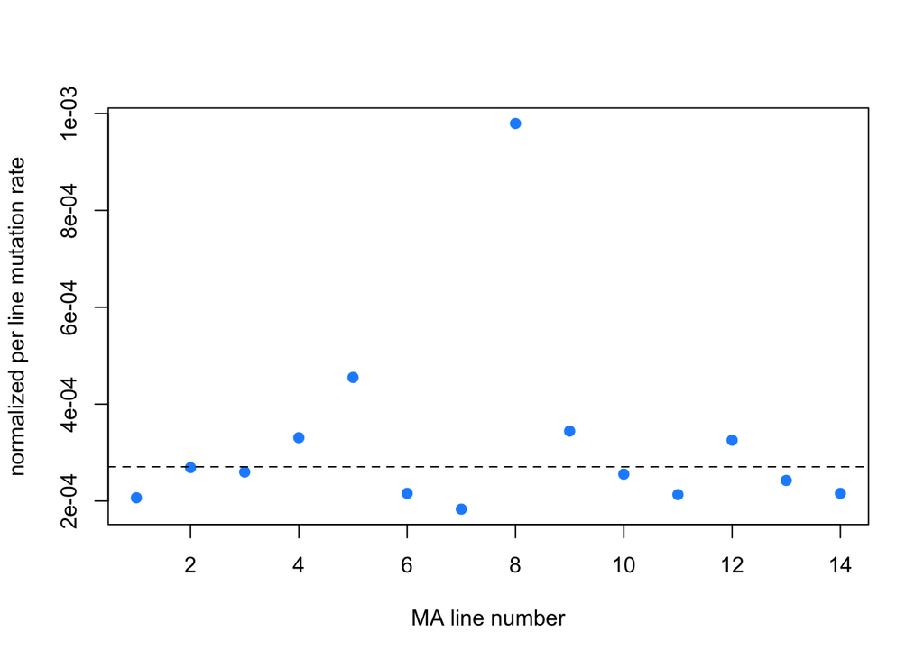

```r
# for presentation
plot(mu_absnorm_perline_1952, xlab="MA line number", ylab="normalized per line mutation rate", pch=19, col="dodgerblue")
abline(h=mean(mu_absnorm_perline_1952[-(which(names(mu_absnorm_perline_1952)=="8"))]), lty=2)
```

# Is there a mutation rate difference in chloroplast-like versus nuclear-like?

## get the per kmer mutation rates, categorize into chloroplast-like and nuclear-like

-These classifications are based on the GC content / length analysis in FileS1

```r
# get per kmer mutation rates.
mu_absnorm_perkmer_1373 <- colMeans(mu_absnorm_1373)
mu_absnorm_perkmer_1373
```

```
##                  AC                 AGC                   C
##        2.075024e-04        4.983813e-05        1.731444e-03
##              AGGCGG                 AAT                AGGC
##        1.317665e-04        6.442355e-04        1.955762e-04
##                ACGC                 AAC              ACACGC
##        3.230863e-04        6.163202e-04        2.011561e-04
## AAATACCTTACGGGAATAT              AGGCGC              ACCGGC
##        4.818706e-04        1.976396e-04        1.891609e-04
##                 CCG                 ACC               AGGGC
##        5.191117e-04        2.738837e-04        3.940864e-04
##              ACCCGC          AAATAACAAT              AGCGGC
##        3.346566e-04        3.558973e-04        2.309949e-04
##               AAAGT                 AGG              ACAGGG
##        5.845884e-04        3.583916e-04        2.406106e-04
##                 ATC              ACGCCC  AAATACTTACGGGAATAT
##        5.907753e-04        3.355285e-04        5.431238e-04
##              AGCGCC              AGCGGG              ACCCGG
##        2.181667e-04        1.429132e-04        4.321513e-04
```

```r
cp_kmers_1373 <- c("AAATACCTTACGGGAATAT", "AAATAACAAT", "AAATACTTACGGGAATAT")
cp_mudf_1373 <- data.frame(as.vector(mu_absnorm_1373[,cp_kmers_1373]), "Chloroplast")
colnames(cp_mudf_1373) <- c("mu", "origin")

nuc_kmers_1373 <- mu_absnorm_1373[,!(colnames(mu_absnorm_1373) %in% cp_kmers_1373)]
nuc_mudf_1373 <- data.frame(as.vector(nuc_kmers_1373), "Nuclear")
colnames(nuc_mudf_1373) <- c("mu", "origin")

##
mu_absnorm_perkmer_1952 <- colMeans(mu_absnorm_1952)
mu_absnorm_perkmer_1952
```

```
##                  AC                 AGC                   C
##        1.966677e-04        3.368259e-05        1.300830e-03
##              AGGCGG                 AAT                AGGC
##        1.883122e-04        5.062102e-04        1.643164e-04
##                ACGC                 AAC              ACACGC
##        2.653587e-04        2.372420e-04        2.039946e-04
## AAATACCTTACGGGAATAT              AGGCGC     AAATTTATATACTCC
##        4.939957e-04        1.775659e-04        4.740304e-04
##              ACCGGC                 CCG                 ACC
##        2.283212e-04        3.503600e-04        2.503913e-04
##               AGGGC              ACCCGC              ACAGGC
##        3.792537e-04        3.414829e-04        1.235683e-04
##              AGCGGC               AAAGT                 AGG
##        1.864214e-04        2.857166e-04        2.720826e-04
##              ACCAGC    AAAGAAGTATATAAAT                 ATC
##        1.315013e-04        5.127602e-04        2.194867e-04
## AAAATATATAAATATAGCT  AAATACTTACGGGAATAT              AGCCGG
##        4.919102e-04        4.098211e-04        2.351175e-04
##              AGCGGG              AGCCGC        AATAGATAATAT
##        1.496758e-04        2.547957e-04        5.697290e-04
```

```r
cp_kmers_1952 <- c("AATAGATAATAT", "AAATACTTACGGGAATAT", "AAAATATATAAATATAGCT", "AAAGAAGTATATAAAT", "AAATTTATATACTCC", "AAATACCTTACGGGAATAT")
cp_mudf_1952 <- data.frame(as.vector(mu_absnorm_1952[,cp_kmers_1952]), "Chloroplast")
colnames(cp_mudf_1952) <- c("mu", "origin")

nuc_kmers_1952 <- mu_absnorm_1952[,!(colnames(mu_absnorm_1952) %in% cp_kmers_1952)]
nuc_mudf_1952 <- data.frame(as.vector(nuc_kmers_1952), "Nuclear")
colnames(nuc_mudf_1952) <- c("mu", "origin")

##
mu_absnorm_perkmer_2342 <- colMeans(mu_absnorm_2342)
mu_absnorm_perkmer_2342
```

```
##                   AC                  AGC                    C
##         2.227022e-04         4.320247e-05         9.807578e-04
##               AGGCGG                  AAT                 AGGC
##         3.357536e-04         6.185956e-04         5.942417e-04
##       AAATAGCAGTATAT                 ACGC                  AAC
##         6.378136e-04         5.032360e-04         5.666532e-04
##               ACACGC               AGGCGC               ACCGGC
##         3.046311e-04         4.147004e-04         3.036452e-04
##                  CCG                  ACC                AGGGC
##         4.641469e-04         2.574642e-04         6.078695e-04
##               ACCCGC               ACAGGC               AGCGGC
##         3.704638e-04         3.362907e-04         3.616134e-04
##                  AGG               ACCAGC               ACAGGG
##         1.707758e-04         2.160528e-04         2.655645e-04
##               ACGCCC AAAAAGGTAAATGTATTTAT                ACGCC
##         2.535651e-04         5.541306e-04         3.302710e-04
##               AGCCGG               AGCGCC               AGGGCC
##         3.360595e-04         4.353515e-04         3.573969e-04
##      ACCTCCGCCTGCCCC               AGAGGC
##         6.446350e-04         3.672816e-04
```

```r
cp_kmers_2342 <- c("AAAAAGGTAAATGTATTTAT")
cp_mudf_2342 <- data.frame(as.vector(mu_absnorm_2342[,cp_kmers_2342]), "Chloroplast")
colnames(cp_mudf_2342) <- c("mu", "origin")

nuc_kmers_2342 <- mu_absnorm_2342[,!(colnames(mu_absnorm_2342) %in% cp_kmers_2342)]
nuc_mudf_2342 <- data.frame(as.vector(nuc_kmers_2342), "Nuclear")
colnames(nuc_mudf_2342) <- c("mu", "origin")

##

mu_absnorm_perkmer_2344 <- colMeans(mu_absnorm_2344)
mu_absnorm_perkmer_2344
```

```
##                  AC                 AGC                   C
##        1.655651e-04        2.694678e-05        1.216203e-03
##              AGGCGG                 AAT                AGGC
##        1.408569e-04        8.581872e-04        1.949342e-04
##                ACGC                 AAC              ACACGC
##        2.261286e-04        5.067335e-04        1.238182e-04
## AAATACCTTACGGGAATAT              AGGCGC     AAATTTATATACTCC
##        4.030395e-04        1.313050e-04        4.567756e-04
##              ACCGGC        AAAATAAAGTGT                 CCG
##        1.126527e-04        3.667549e-04        1.867634e-04
##                 ACC               AGGGC              ACCCGC
##        1.398155e-04        3.417784e-04        2.711734e-04
##              ACAGGC              AGCGGC               AAAGT
##        1.361681e-04        1.415082e-04        2.295498e-04
##                 AGG              ACCAGC              ACAGGG
##        1.394387e-04        1.081513e-04        1.753336e-04
##              AGCGCC
##        1.415283e-04
```

```r
cp_kmers_2344 <- c("AAAATAAAGTGT", "AAATACCTTACGGGAATAT", "AAATTTATATACTCC")
cp_mudf_2344 <- data.frame(as.vector(mu_absnorm_2344[,cp_kmers_2344]), "Chloroplast")
colnames(cp_mudf_2344) <- c("mu", "origin")

nuc_kmers_2344 <- mu_absnorm_2344[,!(colnames(mu_absnorm_2344) %in% cp_kmers_2344)]
nuc_mudf_2344 <- data.frame(as.vector(nuc_kmers_2344), "Nuclear")
colnames(nuc_mudf_2344) <- c("mu", "origin")

##

mu_absnorm_perkmer_2931 <- colMeans(mu_absnorm_2931)
mu_absnorm_perkmer_2931
```

```
##                   AC                  AGC                    C
##         0.0002417023         0.0000466329         0.0006198908
##               AGGCGG                  AAT                 AGGC
##         0.0001481912         0.0006917873         0.0001503861
##       AAATAGCAGTATAT                 ACGC                  AAC
##         0.0005226218         0.0001519168         0.0003483609
##               ACACGC               AGGCGC               ACCGGC
##         0.0001678404         0.0001277948         0.0001332198
##         AAAATAAAGTGT                  CCG                  ACC
##         0.0005215442         0.0002404595         0.0001442657
##                AGGGC               ACCCGC               ACAGGC
##         0.0002141649         0.0002343570         0.0001576606
##               AGCGGC                AAAGT                  AGG
##         0.0001618876         0.0003177009         0.0001902525
##               ACCAGC               ACAGGG                  ATC
##         0.0001373198         0.0001549644         0.0002741911
##               ACGCCC AAAAAGGTAAATGTATTTAT                ACGCC
##         0.0002642346         0.0005099096         0.0001857517
##              ACTGGGC
##         0.0003225799
```

```r
cp_kmers_2931 <- c("AAAAAGGTAAATGTATTTAT", "AAATAGCAGTATAT", "AAAATAAAGTGT")
cp_mudf_2931 <- data.frame(as.vector(mu_absnorm_2931[,cp_kmers_2931]), "Chloroplast")
colnames(cp_mudf_2931) <- c("mu", "origin")

nuc_kmers_2931 <- mu_absnorm_2931[,!(colnames(mu_absnorm_2931) %in% cp_kmers_2931)]
nuc_mudf_2931 <- data.frame(as.vector(nuc_kmers_2931), "Nuclear")
colnames(nuc_mudf_2931) <- c("mu", "origin")

##
mu_absnorm_perkmer_2937 <- colMeans(mu_absnorm_2937)
mu_absnorm_perkmer_2937
```

```
##                  AC                 AGC                   C
##        2.340188e-04        5.601193e-05        1.028693e-03
##              AGGCGG                 AAT                AGGC
##        2.518941e-04        3.599244e-04        2.022858e-04
##                ACGC                 AAC              ACACGC
##        2.567291e-04        3.199280e-04        3.613173e-04
## AAATACCTTACGGGAATAT              AGGCGC              ACCGGC
##        7.496863e-04        1.761667e-04        2.367516e-04
##                 CCG                 ACC               AGGGC
##        1.028518e-03        2.608772e-04        3.154474e-04
##              ACCCGC              ACAGGC              AGCGGC
##        2.593252e-04        1.834435e-04        1.761801e-04
##               AAAGT                 AGG              ACCAGC
##        2.382507e-04        2.879425e-04        1.330499e-04
##              ACAGGG              ACGCCC  AAATACTTACGGGAATAT
##        2.095491e-04        4.378483e-04        5.483755e-04
##               ACGCC              AGCGGG              AAACAC
##        2.441351e-04        3.821426e-04        4.037031e-04
##                AAAC
##        1.966332e-04
```

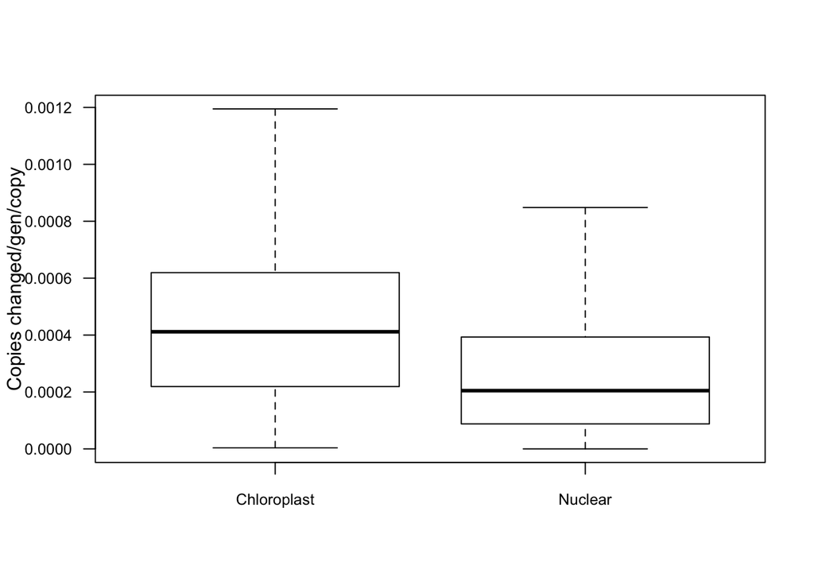

```r
cp_kmers_2937 <- c("AAATACTTACGGGAATAT", "AAATACCTTACGGGAATAT")
cp_mudf_2937 <- data.frame(as.vector(mu_absnorm_2937[,cp_kmers_2937]), "Chloroplast")
colnames(cp_mudf_2937) <- c("mu", "origin")

nuc_kmers_2937 <- mu_absnorm_2937[,!(colnames(mu_absnorm_2937) %in% cp_kmers_2937)]
nuc_mudf_2937 <- data.frame(as.vector(nuc_kmers_2937), "Nuclear")
colnames(nuc_mudf_2937) <- c("mu", "origin")

# now combine all the dataframes and make a boxplot

nuc.cp_df_all <- rbind (cp_mudf_1373, cp_mudf_1952, cp_mudf_2342, cp_mudf_2344, cp_mudf_2931, cp_mudf_2937, nuc_mudf_1373, nuc_mudf_1952, nuc_mudf_2342, nuc_mudf_2344, nuc_mudf_2931, nuc_mudf_2937)
boxplot (mu ~ origin, data=nuc.cp_df_all, las=1, cex.axis=0.8, ylab="Copies changed/gen/copy", outline=F)
```

```r
# chloroplast-like repeats have mutation rates a bit higher (by ANOVA)

nuc.cp_model <- lm(formula = mu ~ origin, data = nuc.cp_df_all)
summary(nuc.cp_model)
```

```
##
## Call:
## lm(formula = mu ~ origin, data = nuc.cp_df_all)
##
## Residuals:
##        Min         1Q     Median         3Q        Max
## -0.0004949 -0.0002253 -0.0001026  0.0000916  0.0064008
##
## Coefficients:
##                 Estimate Std. Error t value Pr(>|t|)
## (Intercept)    4.985e-04  2.665e-05   18.71  < 2e-16 ***
## originNuclear -1.895e-04  2.825e-05   -6.71 2.46e-11 ***
## ---
## Signif. codes:  0 '***' 0.001 '**' 0.01 '*' 0.05 '.' 0.1 ' ' 1
##
## Residual standard error: 0.0004196 on 2248 degrees of freedom
## Multiple R-squared:  0.01964,    Adjusted R-squared:  0.0192
## F-statistic: 45.02 on 1 and 2248 DF,  p-value: 2.455e-11
```

```r
aov(nuc.cp_model)
```

```
## Call:
##    aov(formula = nuc.cp_model)
##
## Terms:
##                       origin    Residuals
## Sum of Squares  0.0000079278 0.0003958247
## Deg. of Freedom            1         2248
##
## Residual standard error: 0.0004196172
## Estimated effects may be unbalanced
```

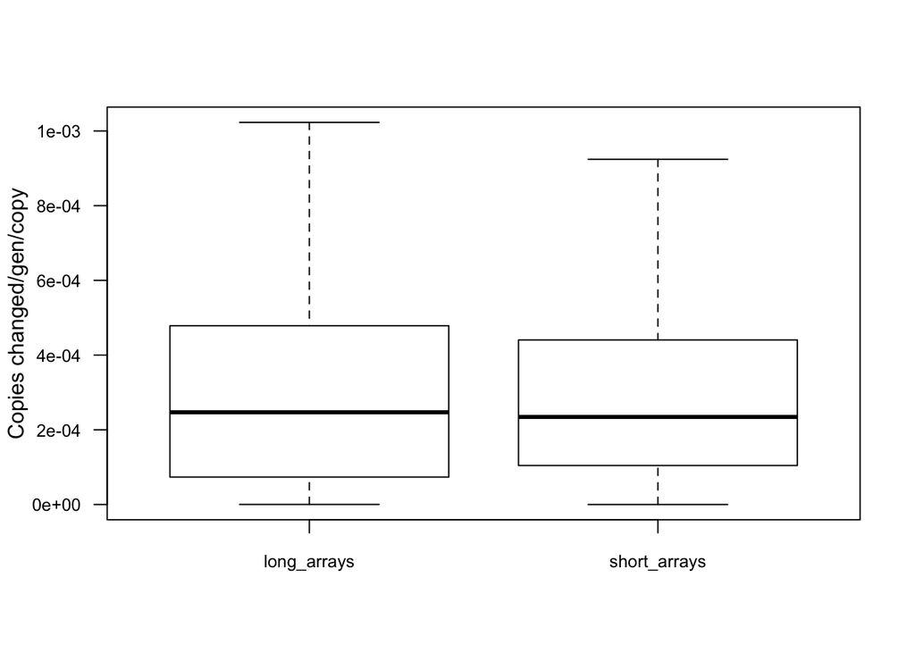

```r
 load("/Users/jullienflynn/Documents/AndyLab/Chlamy/PostReview/kmers_long_arrays_byline.txt")


# go through for each ancestor then put in a big dataframe to plot
## remove specific element from the list: remove the telomere repeat
### 1373 ###
to_remove <- which(kmers_long_arrays_byline[[1]]=="AAAACCCT")
kmers_long_arrays_1373 <- kmers_long_arrays_byline[[1]]
kmers_long_arrays_1373 <- kmers_long_arrays_1373[-to_remove]
longdf_1373 <- data.frame(as.vector(mu_absnorm_1373[,kmers_long_arrays_1373]), "long_arrays")
colnames(longdf_1373) <-c ("mu", "array_type")

kmers_short_arrays_1373 <- mu_absnorm_1373[,!(colnames(mu_absnorm_1373) %in% kmers_long_arrays_1373)]
shortdf_1373 <- data.frame(as.vector(kmers_short_arrays_1373), "short_arrays")
colnames(shortdf_1373) <- c("mu", "array_type")

### 1952 ###
to_remove <- which(kmers_long_arrays_byline[[2]]=="AAAACCCT")
kmers_long_arrays_1952 <- kmers_long_arrays_byline[[2]]
kmers_long_arrays_1952 <- kmers_long_arrays_1952[-to_remove]
longdf_1952 <- data.frame(as.vector(mu_absnorm_1952[,kmers_long_arrays_1952]), "long_arrays")
colnames(longdf_1952) <-c ("mu", "array_type")

kmers_short_arrays_1952 <- mu_absnorm_1373[,!(colnames(mu_absnorm_1373) %in% kmers_long_arrays_1952)]
shortdf_1952 <- data.frame(as.vector(kmers_short_arrays_1952), "short_arrays")
colnames(shortdf_1952) <- c("mu", "array_type")


### 2342 ###
to_remove <- which(kmers_long_arrays_byline[[3]]=="AAAACCCT")
kmers_long_arrays_2342 <- kmers_long_arrays_byline[[3]]
kmers_long_arrays_2342 <- kmers_long_arrays_2342[-to_remove]
longdf_2342 <- data.frame(as.vector(mu_absnorm_2342[,kmers_long_arrays_2342]), "long_arrays")
colnames(longdf_2342) <-c ("mu", "array_type")

kmers_short_arrays_2342 <- mu_absnorm_2342[,!(colnames(mu_absnorm_2342) %in% kmers_long_arrays_2342)]
shortdf_2342 <- data.frame(as.vector(kmers_short_arrays_2342), "short_arrays")
colnames(shortdf_2342) <- c("mu", "array_type")

### 2344 ###

to_remove <- which(kmers_long_arrays_byline[[4]]=="AAAACCCT")
kmers_long_arrays_2344 <- kmers_long_arrays_byline[[4]]
kmers_long_arrays_2344 <- kmers_long_arrays_2344[-to_remove]
longdf_2344 <- data.frame(as.vector(mu_absnorm_2344[,kmers_long_arrays_2344]), "long_arrays")
colnames(longdf_2344) <-c ("mu", "array_type")

kmers_short_arrays_2344 <- mu_absnorm_2344[,!(colnames(mu_absnorm_2344) %in% kmers_long_arrays_2344)]
shortdf_2344 <- data.frame(as.vector(kmers_short_arrays_2344), "short_arrays")
colnames(shortdf_2344) <- c("mu", "array_type")

### 2931 ###

to_remove <- which(kmers_long_arrays_byline[[5]]=="AAAACCCT")
kmers_long_arrays_2931 <- kmers_long_arrays_byline[[5]]
kmers_long_arrays_2931 <- kmers_long_arrays_2931[-to_remove]
longdf_2931 <- data.frame(as.vector(mu_absnorm_2931[,kmers_long_arrays_2931]), "long_arrays")
colnames(longdf_2931) <-c ("mu", "array_type")

kmers_short_arrays_2931 <- mu_absnorm_2931[,!(colnames(mu_absnorm_2931) %in% kmers_long_arrays_2931)]
shortdf_2931 <- data.frame(as.vector(kmers_short_arrays_2931), "short_arrays")
colnames(shortdf_2931) <- c("mu", "array_type")

### 2937 ###

to_remove <- which(kmers_long_arrays_byline[[6]]=="AAAACCCT")
kmers_long_arrays_2937 <- kmers_long_arrays_byline[[6]]
kmers_long_arrays_2937 <- kmers_long_arrays_2937[-to_remove]
longdf_2937 <- data.frame(as.vector(mu_absnorm_2937[,kmers_long_arrays_2937]), "long_arrays")
colnames(longdf_2937) <-c ("mu", "array_type")

kmers_short_arrays_2937 <- mu_absnorm_2937[,!(colnames(mu_absnorm_2937) %in% kmers_long_arrays_2937)]
shortdf_2937 <- data.frame(as.vector(kmers_short_arrays_2937), "short_arrays")
colnames(shortdf_2937) <- c("mu", "array_type")

#####
long.short_df_all <- rbind (longdf_1373, longdf_1952, longdf_2342, longdf_2344, longdf_2931, longdf_2937, shortdf_1373, shortdf_1952, shortdf_2342, shortdf_2344, shortdf_2931, shortdf_2937)
boxplot (mu ~ array_type, data=long.short_df_all, las=1, cex.axis=0.8, ylab="Copies changed/gen/copy", outline=F)
```

```r
long.short_model <- lm(formula = mu ~ array_type, data = long.short_df_all)
summary(long.short_model)
```

```
##
## Call:
## lm(formula = mu ~ array_type, data = long.short_df_all)
##
## Residuals:
##        Min         1Q     Median         3Q        Max
## -0.0003433 -0.0002429 -0.0001027  0.0001087  0.0063665
##
## Coefficients:
##                         Estimate Std. Error t value Pr(>|t|)
## (Intercept)            3.398e-04  1.866e-05   18.22   <2e-16 ***
## array_typeshort_arrays 3.433e-06  2.150e-05    0.16    0.873
## ---
## Signif. codes:  0 '***' 0.001 '**' 0.01 '*' 0.05 '.' 0.1 ' ' 1
##
## Residual standard error: 0.0004351 on 2202 degrees of freedom
## Multiple R-squared:  1.159e-05,  Adjusted R-squared:  -0.0004425
## F-statistic: 0.02551 on 1 and 2202 DF,  p-value: 0.8731
```

```r
aov(long.short_model)
```

```
## Call:
##    aov(formula = long.short_model)
##
## Terms:
##                   array_type    Residuals
## Sum of Squares  0.0000000048 0.0004168838
## Deg. of Freedom            1         2202
##
## Residual standard error: 0.0004351098
## Estimated effects may be unbalanced
```

Not a significant difference in the absolute mutation rate of long versus short arrays. Look at directionality now.

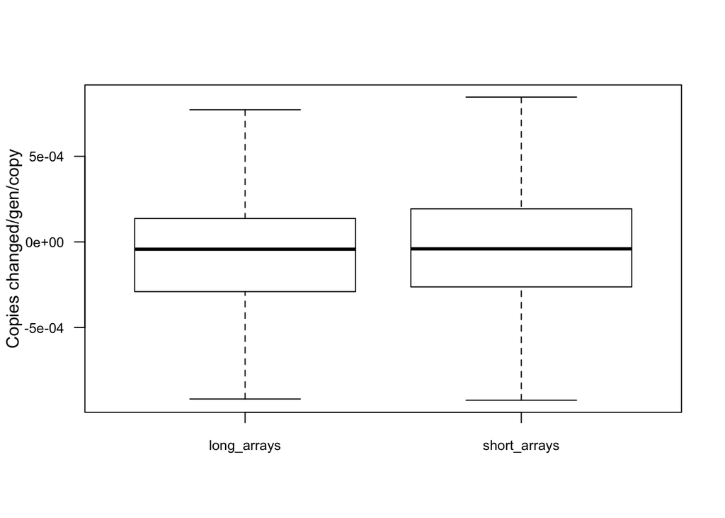

```r
### 1373 ###
longdf_1373 <- data.frame(as.vector(munorm_1373[,kmers_long_arrays_1373]), "long_arrays")
colnames(longdf_1373) <-c ("mu", "array_type")

kmers_short_arrays_1373 <- munorm_1373[,!(colnames(mu_absnorm_1373) %in% kmers_long_arrays_1373)]
shortdf_1373 <- data.frame(as.vector(kmers_short_arrays_1373), "short_arrays")
colnames(shortdf_1373) <- c("mu", "array_type")

### 1952 ###
longdf_1952 <- data.frame(as.vector(munorm_1952[,kmers_long_arrays_1952]), "long_arrays")
colnames(longdf_1952) <-c ("mu", "array_type")

kmers_short_arrays_1952 <- munorm_1373[,!(colnames(mu_absnorm_1373) %in% kmers_long_arrays_1952)]
shortdf_1952 <- data.frame(as.vector(kmers_short_arrays_1952), "short_arrays")
colnames(shortdf_1952) <- c("mu", "array_type")

### 2342 ###
longdf_2342 <- data.frame(as.vector(munorm_2342[,kmers_long_arrays_2342]), "long_arrays")
colnames(longdf_2342) <-c ("mu", "array_type")

kmers_short_arrays_2342 <- munorm_2342[,!(colnames(mu_absnorm_2342) %in% kmers_long_arrays_2342)]
shortdf_2342 <- data.frame(as.vector(kmers_short_arrays_2342), "short_arrays")
colnames(shortdf_2342) <- c("mu", "array_type")

### 2344 ###

longdf_2344 <- data.frame(as.vector(munorm_2344[,kmers_long_arrays_2344]), "long_arrays")
colnames(longdf_2344) <-c ("mu", "array_type")

kmers_short_arrays_2344 <- munorm_2344[,!(colnames(mu_absnorm_2344) %in% kmers_long_arrays_2344)]
shortdf_2344 <- data.frame(as.vector(kmers_short_arrays_2344), "short_arrays")
colnames(shortdf_2344) <- c("mu", "array_type")

### 2931 ###

longdf_2931 <- data.frame(as.vector(munorm_2931[,kmers_long_arrays_2931]), "long_arrays")
colnames(longdf_2931) <-c ("mu", "array_type")

kmers_short_arrays_2931 <- munorm_2931[,!(colnames(mu_absnorm_2931) %in% kmers_long_arrays_2931)]
shortdf_2931 <- data.frame(as.vector(kmers_short_arrays_2931), "short_arrays")
colnames(shortdf_2931) <- c("mu", "array_type")

### 2937 ###

longdf_2937 <- data.frame(as.vector(munorm_2937[,kmers_long_arrays_2937]), "long_arrays")
colnames(longdf_2937) <-c ("mu", "array_type")

kmers_short_arrays_2937 <- munorm_2937[,!(colnames(mu_absnorm_2937) %in% kmers_long_arrays_2937)]
shortdf_2937 <- data.frame(as.vector(kmers_short_arrays_2937), "short_arrays")
colnames(shortdf_2937) <- c("mu", "array_type")

#####
long.short_df_all <- rbind (longdf_1373, longdf_1952, longdf_2342, longdf_2344, longdf_2931, longdf_2937, shortdf_1373, shortdf_1952, shortdf_2342, shortdf_2344, shortdf_2931, shortdf_2937)
boxplot (mu ~ array_type, data=long.short_df_all, las=1, cex.axis=0.8, ylab="Copies changed/gen/copy", outline=F)
```

```r
# There was also ot a difference in directionality.

long.short_model <- lm(formula = mu ~ array_type, data = long.short_df_all)
summary(long.short_model)
```

```
##
## Call:
## lm(formula = mu ~ array_type, data = long.short_df_all)
##
## Residuals:
##        Min         1Q     Median         3Q        Max
## -0.0014507 -0.0002691 -0.0000406  0.0001846  0.0067104
##
## Coefficients:
##                          Estimate Std. Error t value Pr(>|t|)
## (Intercept)             2.011e-06  2.374e-05   0.085    0.933
## array_typeshort_arrays -2.708e-06  2.736e-05  -0.099    0.921
##
## Residual standard error: 0.0005538 on 2202 degrees of freedom
## Multiple R-squared:  4.449e-06,  Adjusted R-squared:  -0.0004497
## F-statistic: 0.009797 on 1 and 2202 DF,  p-value: 0.9212
```

```r
aov(long.short_model)
```

```
## Call:
##    aov(formula = long.short_model)
##
## Terms:
##                   array_type    Residuals
## Sum of Squares  0.0000000030 0.0006753288
## Deg. of Freedom            1         2202
##
## Residual standard error: 0.000553795
## Estimated effects may be unbalanced
```

# Is there variation in mutation rate across ancestors and kmers?

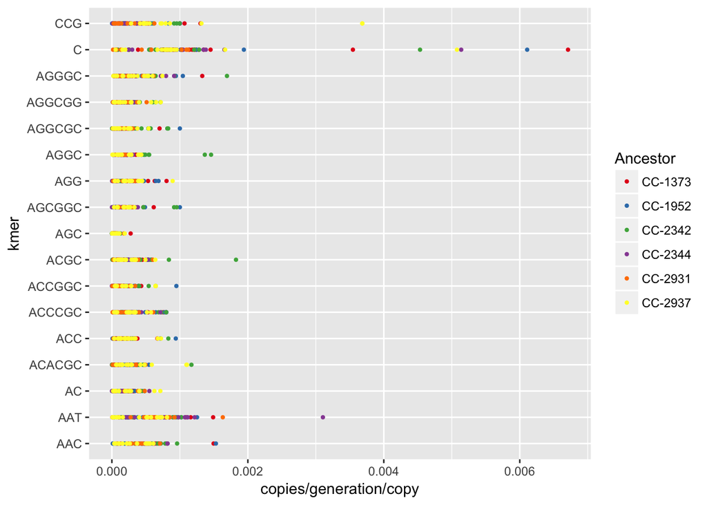

```r
make_df_from_matrix <- function(mx, anc) {
  kmer.names <- c()
  for (i in 1:ncol(mx)) {
  kmer.names <- c(kmer.names, rep(colnames(mx)[i], times=nrow(mx)))
  }
  Mu <- c(mx)
  Ancestor <- anc
  df1 <- data.frame (Mu, kmer.names, Ancestor)
  df2 <- df1[which(as.vector(df1$kmer.names) %in% shared.common.kmers),]
  return(df2)
}

mu_absnorm_df_1373 <- make_df_from_matrix(mu_absnorm_1373, "CC-1373")
mu_absnorm_df_1952 <- make_df_from_matrix(mu_absnorm_1952, "CC-1952")
mu_absnorm_df_2342 <- make_df_from_matrix(mu_absnorm_2342, "CC-2342")
mu_absnorm_df_2344 <- make_df_from_matrix(mu_absnorm_2344, "CC-2344")
mu_absnorm_df_2931 <- make_df_from_matrix(mu_absnorm_2931, "CC-2931")
mu_absnorm_df_2937 <- make_df_from_matrix(mu_absnorm_2937, "CC-2937")

mu_absnorm_df_complete <- rbind (mu_absnorm_df_1373, mu_absnorm_df_1952, mu_absnorm_df_2342, mu_absnorm_df_2344, mu_absnorm_df_2931, mu_absnorm_df_2937)

ggplot(mu_absnorm_df_complete, aes(Mu, kmer.names, colour = Ancestor)) +
  geom_point(size = 0.8) +
  ylab("kmer") +
  xlab("copies/generation/copy") +
  scale_colour_brewer(palette="Set1")
```

```r
# get summaries - mean for each ancestor
# min mutation rate of kmer

mu_means_1373 <- colMeans(mu_absnorm_1373)
mean(mu_means_1373)
```

```
## [1] 0.0003897954
```

```r
mu_means_1373[which(mu_means_1373==min(mu_means_1373))]
```

```
##          AGC
## 4.983813e-05
```

```r
mu_means_1373[which(mu_means_1373==max(mu_means_1373))]
```

```
##           C
## 0.001731444
```

```r
mu_means_1952 <- colMeans(mu_absnorm_1952)
mean(mu_means_1952)
```

```
## [1] 0.0003211534
```

```r
mu_means_1952[which(mu_means_1952==min(mu_means_1952))]
```

```
##          AGC
## 3.368259e-05
```

```r
mu_means_1952[which(mu_means_1952==max(mu_means_1952))]
```

```
##          C
## 0.00130083
```

```r
mu_means_2342 <- colMeans(mu_absnorm_2342)
mean(mu_means_2342)
```

```
## [1] 0.0004087885
```

```r
mu_means_2342[which(mu_means_2342==min(mu_means_2342))]
```

```
##          AGC
## 4.320247e-05
```

```r
mu_means_2342[which(mu_means_2342==max(mu_means_2342))]
```

```
##            C
## 0.0009807578
```

```r
mu_means_2344 <- colMeans(mu_absnorm_2344)
mean(mu_means_2344)
```

```
## [1] 0.0002776444
```

```r
mu_means_2344[which(mu_means_2344==min(mu_means_2344))]
```

```
##          AGC
## 2.694678e-05
```

```r
mu_means_2344[which(mu_means_2344==max(mu_means_2344))]
```

```
##           C
## 0.001216203
```

```r
mu_means_2931 <- colMeans(mu_absnorm_2931)
mean(mu_means_2931)
```

```
## [1] 0.0002636282
```

```r
mu_means_2931[which(mu_means_2931==min(mu_means_2931))]
```

```
##         AGC
## 4.66329e-05
```

```r
mu_means_2931[which(mu_means_2931==max(mu_means_2931))]
```

```
##          AAT
## 0.0006917873
```

```r
mu_means_2931["C"]
```

```
##            C
## 0.0006198908
```

```r
mu_means_2937 <- colMeans(mu_absnorm_2937)
mean(mu_means_2937)
```

```
## [1] 0.0003406725
```

```r
mu_means_2937[which(mu_means_2937==min(mu_means_2937))]
```

```
##          AGC
## 5.601193e-05
```

```r
mu_means_2937[which(mu_means_2937==max(mu_means_2937))]
```

```
##           C
## 0.001028693
```

```r
mean(c(mu_means_1373["C"], mu_means_1952["C"], mu_means_2342["C"], mu_means_2344["C"], mu_means_2931["C"], mu_means_2937["C"]))
```

```
## [1] 0.001146303
```

```r
mean(c(mu_means_1373["AGC"], mu_means_1952["AGC"], mu_means_2342["AGC"], mu_means_2344["AGC"], mu_means_2931["AGC"], mu_means_2937["AGC"]))
```

```
## [1] 4.271913e-05
```

# Is there a relationship between SNP rate and kmer mutation rate? Or indel rate and kmer mutation rate?

## Get average mutation rates (across all kmers) for each MA subline

```r
mu_absnorm_perline_1373 <- rowMeans(mu_absnorm_1373)
names(mu_absnorm_perline_1373) <- as.integer(substr(names(mu_absnorm_perline_1373), start=11, stop=12))

# ensure that in proper order for comparison
mu_absnorm_perline_1952 <- rowMeans(mu_absnorm_1952)
names(mu_absnorm_perline_1952) <- as.integer(substr(names(mu_absnorm_perline_1952), start=11, stop=12))
mu_absnorm_perline_2342 <- rowMeans(mu_absnorm_2342)
names(mu_absnorm_perline_2342) <- as.integer(substr(names(mu_absnorm_perline_2342), start=11, stop=12))
mu_absnorm_perline_2344 <- rowMeans(mu_absnorm_2344)
names(mu_absnorm_perline_2344) <- as.integer(substr(names(mu_absnorm_perline_2344), start=11, stop=12))
mu_absnorm_perline_2931 <- rowMeans(mu_absnorm_2931)
names(mu_absnorm_perline_2931) <- as.integer(substr(names(mu_absnorm_perline_2931), start=11, stop=12))
mu_absnorm_perline_2937 <- rowMeans(mu_absnorm_2937)
names(mu_absnorm_perline_2937) <- as.integer(substr(names(mu_absnorm_perline_2937), start=11, stop=12))
```